# Analysis of catch sizes for european tuna seiners and maldivian pole-and-line vessels

Augustin Lafond

August 02, 2023

We load the packages

```r
source("https://www.dropbox.com/s/lzdnoe69iex1le1/load_packages.R?dl=1") #Load packages

load_packages("lubridate",
              "tidyverse",
              "readxl",
              "openxlsx",
              "janitor",
              "grid",
              "RCurl",
              "kableExtra",
              "jpeg")
```

# In this section, we compare the size of tuna caught by European purse seiners vs. Maldivian pole and liners

Data on tuna size caught in the Indian ocean can be downloaded at : https://iotc.org/data/datasets

```r
file_names <- paste0("data/catch size/", list.files ("data/catch size") %>%
  as_tibble () %>%
  filter (str_detect(value, "IOTC-DATASETS") == TRUE) %>%
  pull (value))

data_size <- lapply(file_names, read_xlsx, 2)

for (i in 1:length(data_size)) {
  data_size [[i]] <- data_size [[i]] %>%
    clean_names ()
}

data_size <- do.call("rbind", data_size)
```

```r
data_size_plot <- data_size %>%
  filter (fleet_code %in% c("EUESP", "EUFRA", "MDV") & year > 2014 & !gear_code == "TROL") %>%
  mutate(gear_code = case_when (gear_code %in% c("BBOF", "BB") ~ "Canne (Maldives)",
                                gear_code %in% c("HLOF", "HAND") ~ "Filet (Maldives)",
                                gear_code == "LL" ~ "Palangre (Maldives)",
                                gear_code == "PS" ~ "Senne (UE)"),
         species_code = case_when (species_code == "BET" ~ "Thon Obèse",
                                    species_code == "SKJ" ~ "Thon Listao (ou Bonite)",
                                    species_code == "YFT" ~ "Thon Albacore"),
         species_code = factor(species_code, levels = c("Thon Obèse", "Thon Listao (ou Bonite)", "Thon Albacore"))) %>%
  group_by(gear_code, species_code, school_type_code, first_class_low, size_interval) %>%
  summarise_at(vars(matches(c("c0|c1"))), ~ sum(.)) %>%
  ungroup () %>%
  pivot_longer (cols = 6:ncol(.), names_to = "size_bin", values_to = "fish_nb") %>%
  with_groups (c("gear_code", "species_code", "school_type_code"), mutate, fish_freq = fish_nb/sum(fish_nb)) %>%
  mutate (size_min = first_class_low + (as.numeric(str_extract(size_bin, "[0-9]+"))-1) * size_interval,
          size_max = first_class_low + as.numeric(str_extract(size_bin, "[0-9]+")) * size_interval,
          size_mean = (size_min + size_max)/2,
          size_juvenile = case_when (species_code == "Thon Obèse" ~ 112.5,
                                     species_code == "Thon Listao (ou Bonite)" ~ 46,
                                     species_code == "Thon Albacore" ~ 103.3))
```

Estimating the absolute volume of tuna caught by the maldivian baitboat and european purse seiners per year

```r
catch_iotc <- readRDS ("data/iotc_spatial.rds") %>%
  filter (((country == "Spain" & gear == "Purse seine") | (country == "France" & gear == "Purse seine") | (country == "Maldives" & grepl("Baitboat", gear))) & year > 2014 & species %in% c("Yellowfin tuna", "Bigeye tuna", "Skipjack tuna")) %>%
  mutate(country = ifelse(country %in% c("France", "Spain"), "EU", country)) %>%
  with_groups (c("country", "year", "species"), summarise, catch = sum(catch, na.rm = T)) %>%
  with_groups(c("country", "species"), summarise, catch = mean(catch))
```

Size frequency distribution of the catches (relative) for Maldivian fisheries and European purse seine fishery without distinction of the type of set (FAD vs. FS)

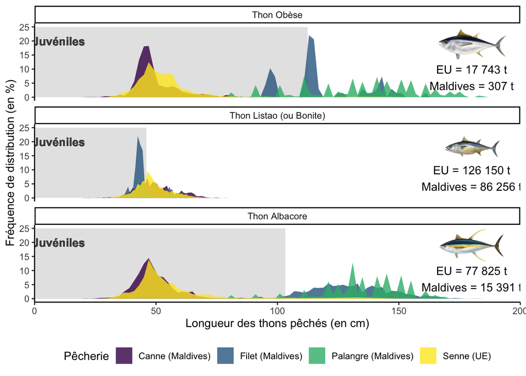

```r
annotation <- data.frame (species_code = factor (c("Thon Obèse", "Thon Listao (ou Bonite)", "Thon Albacore")), text = c(paste0("EU = ", catch_iotc %>% filter (species == "Bigeye tuna" & country == "EU") %>% mutate(catch = format(round(catch,0), big.mark =" ")) %>% pull (catch), " t\nMaldives = ", catch_iotc %>% filter (species == "Bigeye tuna" & country == "Maldives") %>% mutate(catch = format(round(catch,0), big.mark =" ")) %>% pull (catch), " t"),
  paste0("EU = ", catch_iotc %>% filter (species == "Skipjack tuna" & country == "EU") %>% mutate(catch = format(round(catch,0), big.mark =" ")) %>% pull (catch), " t\nMaldives = ", catch_iotc %>% filter (species == "Skipjack tuna" & country == "Maldives") %>% mutate(catch = format(round(catch,0), big.mark =" ")) %>% pull (catch), " t"),
  paste0("EU = ", catch_iotc %>% filter (species == "Yellowfin tuna" & country == "EU") %>% mutate(catch = format(round(catch,0), big.mark =" ")) %>% pull (catch), " t\nMaldives = ", catch_iotc %>% filter (species == "Yellowfin tuna" & country == "Maldives") %>% mutate(catch = format(round(catch,0), big.mark =" ")) %>% pull (catch), " t")), x1 = c(180, 180, 180), y1 = c(7, 7, 7))


img1 = readJPEG("input/tuna images/big_eye.jpg")
img2 = readJPEG("input/tuna images/skipjack.jpg")
img3 = readJPEG("input/tuna images/yellowfin.jpg")

annotation_custom2 <-
function (grob, xmin = -Inf, xmax = Inf, ymin = -Inf, ymax = Inf, data){ layer(data = data, stat = StatIdentity, position = PositionIdentity,
        geom = ggplot2:::GeomCustomAnn,
        inherit.aes = TRUE, params = list(grob = grob,
                                          xmin = xmin, xmax = xmax,
                                          ymin = ymin, ymax = ymax))}

a1 = annotation_custom2(rasterGrob(img1, interpolate=TRUE), xmin=160, xmax=200, ymin=13, ymax=25, data_size_plot %>% filter(species_code == "Thon Obèse") %>% slice(1))
a2 = annotation_custom2(rasterGrob(img2, interpolate=TRUE), xmin=160, xmax=200, ymin=12, ymax=24, data_size_plot %>% filter(species_code == "Thon Listao (ou Bonite)") %>% slice(1))
a3 = annotation_custom2(rasterGrob(img3, interpolate=TRUE),xmin=160, xmax=200, ymin=13, ymax=25, data_size_plot %>% filter(species_code == "Thon Albacore") %>% slice(1))


p <- ggplot(data_size_plot %>%
         with_groups (c("gear_code", "species_code", "size_mean", "size_juvenile"), summarise, fish_nb = sum(fish_nb)) %>%
         with_groups (c("gear_code", "species_code"), mutate, fish_freq = fish_nb*100/sum(fish_nb)), aes(x = size_mean, y = fish_freq)) +
  geom_rect(aes(xmin=0, xmax=size_juvenile, ymin=0, ymax=25), fill = "grey90") +
  geom_area(aes(fill = gear_code), position = "identity", alpha = 0.8) +
  geom_text (data = annotation, aes(x = x1, y = y1, label = text)) +
  geom_text (aes(x = 10, y = 20, label = "Juvéniles"), color = "grey30", fontface='bold') +
  facet_wrap(~species_code, ncol = 1) +
  theme_classic () +
  scale_fill_viridis_d (option = "viridis") +
  labs (y = "Fréquence de distribution (en %)", x = "Longueur des thons pêchés (en cm)", fill = "Pêcherie") +
  scale_x_continuous(limits = c(0,200), expand = c(0,0)) +
  theme(legend.position="bottom")

p + a1 + a2 + a3
```

```r
ggsave(file = "Output//Size frequency distribution_2.pdf", width = 26, height = 18, unit = "cm", limitsize = FALSE)
```

## Size frequency distribution of the catches (absolute) for Maldivian pole and line

What we observe is that the length frequency distribution of tuna caught by maldivian baitboat under anchored FAD and on free school is similar.

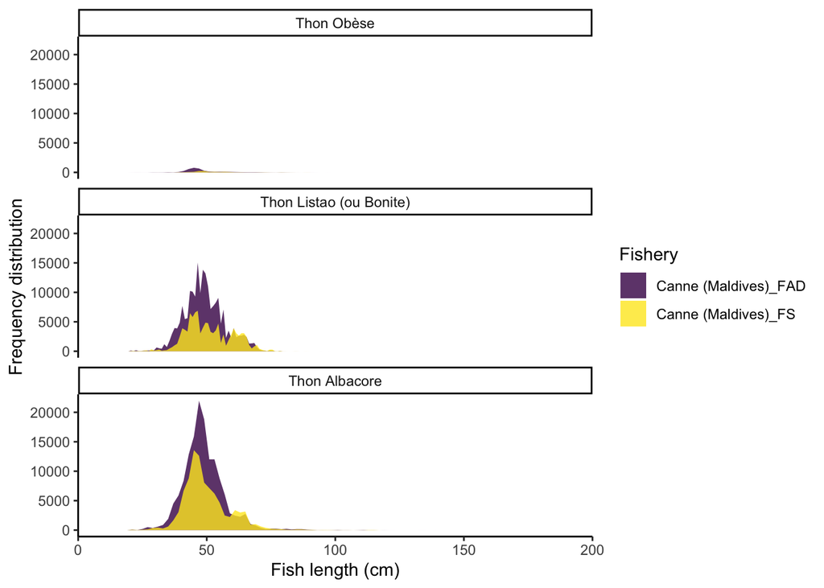

```r
ggplot(data_size_plot %>%
         filter (gear_code %in% c("Canne (Maldives)", "Senne (UE)") & !school_type_code %in% c("UNCL", "FD")) %>%
         mutate (school_type_code = ifelse(school_type_code %in% c("LS", "LA"), "FAD", school_type_code)) %>%
         with_groups(c("gear_code", "species_code", "school_type_code", "size_mean"), summarise, fish_nb = sum(fish_nb, na.rm = T)) %>%
         mutate (fishery = paste0(gear_code, "_", school_type_code)) %>%
         filter (gear_code == "Canne (Maldives)"), aes(x = size_mean, y = fish_nb, fill = fishery)) +
    geom_area(position = "identity", alpha = 0.8) +
    facet_wrap(~species_code, ncol = 1) +
    theme_classic () +
    scale_fill_viridis_d (option = "viridis") +
    labs (y = "Frequency distribution", x = "Fish length (cm)", fill = "Fishery") +
    scale_x_continuous(limits = c(0,200), expand = c(0,0))
```

## Size frequency distribution of the catches (relative) for Maldivian pole and line

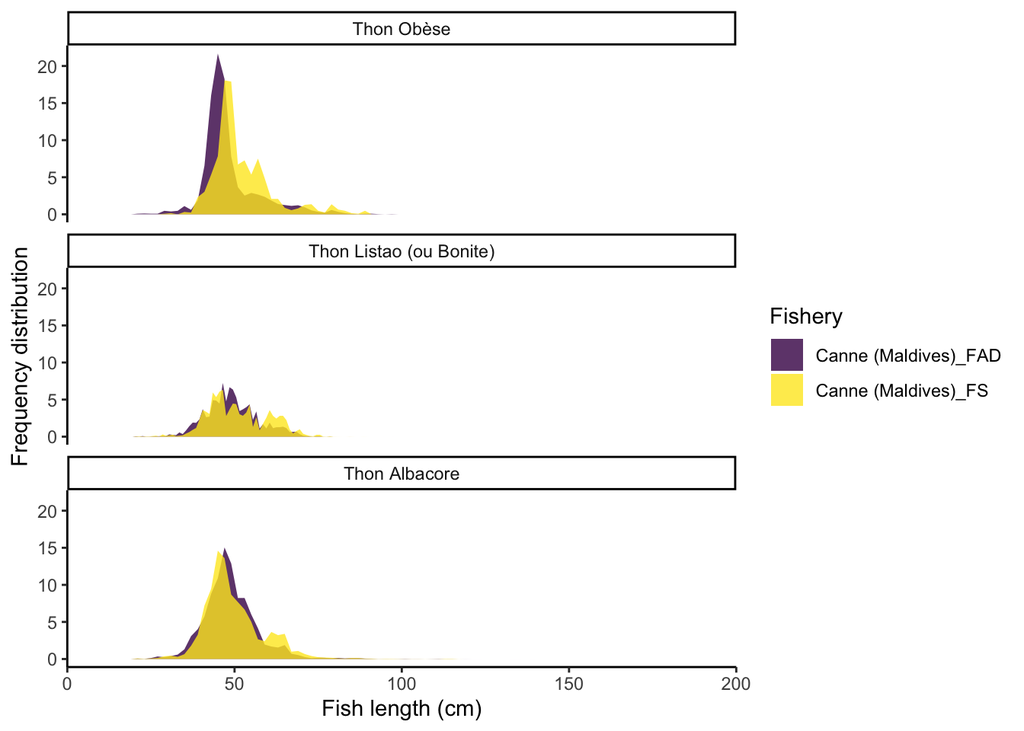

```r
ggplot(data_size_plot %>%
         filter (gear_code %in% c("Canne (Maldives)", "Senne (UE)") & !school_type_code %in% c("UNCL", "FD")) %>%
         mutate (school_type_code = ifelse(school_type_code %in% c("LS", "LA"), "FAD", school_type_code)) %>%
         with_groups(c("gear_code", "species_code", "school_type_code", "size_mean"), summarise, fish_nb = sum(fish_nb, na.rm = T)) %>%
         mutate (fishery = paste0(gear_code, "_", school_type_code)) %>%
         filter (gear_code == "Canne (Maldives)") %>%
         with_groups (c("species_code", "school_type_code"), mutate, frequency = fish_nb*100/sum(fish_nb)), aes(x = size_mean, y = frequency, fill = fishery)) +
    geom_area(position = "identity", alpha = 0.8) +
    facet_wrap(~species_code, ncol = 1) +
    theme_classic () +
    scale_fill_viridis_d (option = "viridis") +
    labs (y = "Frequency distribution", x = "Fish length (cm)", fill = "Fishery") +
    scale_x_continuous(limits = c(0,200), expand = c(0,0))
```

## Size frequency distribution of the catches (absolute) for European purse seine

The absolute number of tuna caught under free swimming school by EU purse seiners is almost null.

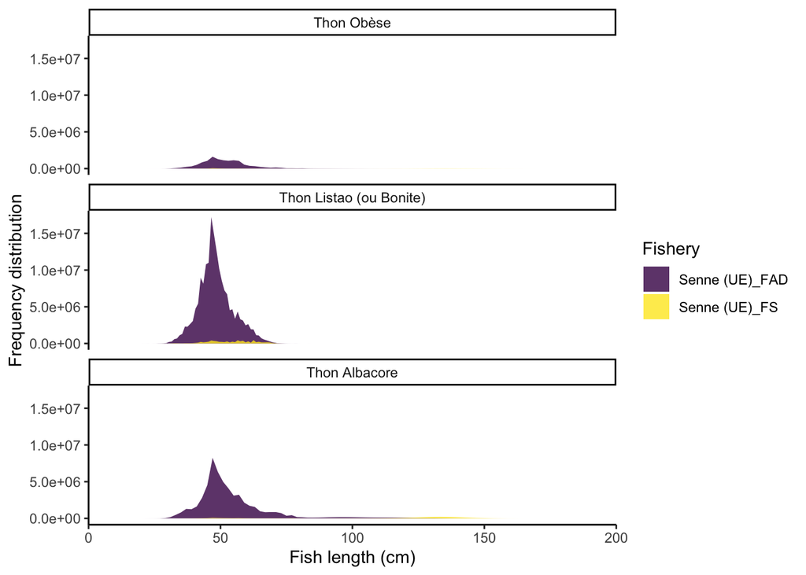

```r
ggplot(data_size_plot %>%
           filter (gear_code %in% c("Canne (Maldives)", "Senne (UE)") & !school_type_code %in% c("UNCL", "FD")) %>%
           mutate (school_type_code = ifelse(school_type_code %in% c("LS", "LA"), "FAD", school_type_code)) %>%
           with_groups(c("gear_code", "species_code", "school_type_code", "size_mean"), summarise, fish_nb = sum(fish_nb, na.rm = T)) %>%
           mutate (fishery = paste0(gear_code, "_", school_type_code)) %>%
           filter (gear_code == "Senne (UE)"), aes(x = size_mean, y = fish_nb, fill = fishery)) +
    geom_area(position = "identity", alpha = 0.8) +
    facet_wrap(~species_code, ncol = 1) +
    theme_classic () +
    scale_fill_viridis_d (option = "viridis") +
    labs (y = "Frequency distribution", x = "Fish length (cm)", fill = "Fishery") +
    scale_x_continuous(limits = c(0,200), expand = c(0,0))
```

## Size frequency distribution of the catches (relative) for European purse seine

However, we clearly see that tuna caught under free swimming schools are much larger than those caught under dFAD, especially for Yellowfin and Big eye tunas.

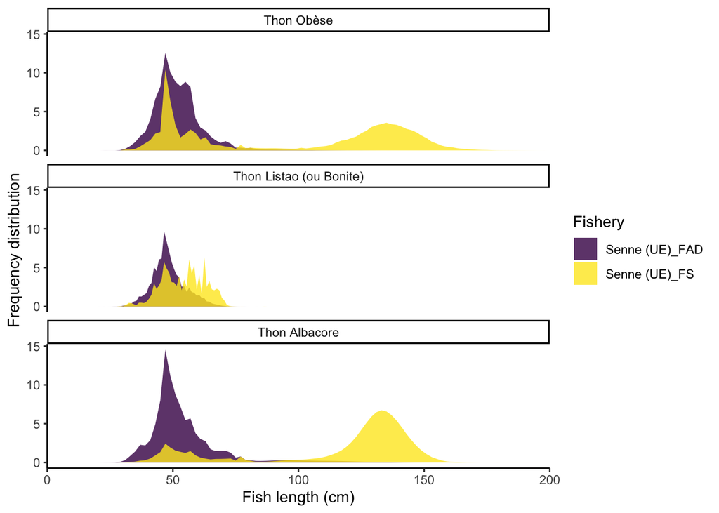

```r
ggplot(data_size_plot %>%
         filter (gear_code %in% c("Canne (Maldives)", "Senne (UE)") & !school_type_code %in% c("UNCL", "FD")) %>%
         mutate (school_type_code = ifelse(school_type_code %in% c("LS", "LA"), "FAD", school_type_code)) %>%
         with_groups(c("gear_code", "species_code", "school_type_code", "size_mean"), summarise, fish_nb = sum(fish_nb, na.rm = T)) %>%
         mutate (fishery = paste0(gear_code, "_", school_type_code)) %>%
         filter (gear_code == "Senne (UE)") %>%
         with_groups (c("species_code", "school_type_code"), mutate, frequency = fish_nb*100/sum(fish_nb)), aes(x = size_mean, y = frequency, fill = fishery)) +
    geom_area(position = "identity", alpha = 0.8) +
    facet_wrap(~species_code, ncol = 1) +
    theme_classic () +
    scale_fill_viridis_d (option = "viridis") +
    labs (y = "Frequency distribution", x = "Fish length (cm)", fill = "Fishery") +
    scale_x_continuous(limits = c(0,200), expand = c(0,0))
```

Percent of juvenile according to fishery

```r
juvenile_perc <- data_size_plot %>%
  filter (gear_code %in% c("Canne (Maldives)", "Senne (UE)")) %>%
  mutate(school_type = case_when (school_type_code == "FD" ~ "Free school dolphin Associated",
                                  school_type_code == "FS" ~ "Free-swimming school",
                                  school_type_code == "LA" ~ "Associated school anchored-FAD",
                                  school_type_code == "LS" ~ "Drifting Log or FAD-associated",
                                  school_type_code == "UNCL" ~ "Unknown")) %>%
  with_groups(c("gear_code", "species_code", "school_type", "size_mean"), summarise, fish_nb = sum(fish_nb, na.rm = T)) %>%
    mutate (juvenile = case_when(species_code == "Thon Obèse" & size_mean < 112.5 ~"TRUE",
                                 species_code == "Thon Listao (ou Bonite)" & size_mean < 46 ~ "TRUE",
                                 species_code == "Thon Albacore" & size_mean < 103.3 ~"TRUE"),
            juvenile = ifelse(is.na(juvenile), FALSE, juvenile),
            size_tot = fish_nb * size_mean) %>%
  with_groups(c("gear_code", "species_code", "school_type", "juvenile"), summarise, fish_nb = sum(fish_nb), size_tot = sum(size_tot)) %>%
  with_groups(c("gear_code", "species_code", "school_type"), mutate, fish_perc = round(fish_nb*100/sum(fish_nb), 1), size_mean = round(sum(size_tot)/sum(fish_nb),1))

#Let's create a table
juvenile_perc %>%
  kable () %>%
  kable_paper(full_width = T) %>%
  kable_styling(bootstrap_options = c("striped", "condensed", "responsive", "hover")) %>%
  row_spec(0, bold = TRUE)
```

| gear_code | species_code | school_type | juvenile | fish_nb | size_tot | fish_perc | size_mean |
| --- | --- | --- | --- | --- | --- | --- | --- |
| Canne (Maldives) | Thon Obèse | Associated school anchored-FAD | FALSE | 0 | 0.0 | 0.0 | 48.5 |
| Canne (Maldives) | Thon Obèse | Associated school anchored-FAD | TRUE | 3497 | 169597.0 | 100.0 | 48.5 |
| Canne (Maldives) | Thon Obèse | Drifting Log or FAD-associated | FALSE | 0 | 0.0 | 0.0 | 43.2 |
| Canne (Maldives) | Thon Obèse | Drifting Log or FAD-associated | TRUE | 105 | 4531.0 | 100.0 | 43.2 |
| Canne (Maldives) | Thon Obèse | Free-swimming school | FALSE | 0 | 0.0 | 0.0 | 52.0 |
| Canne (Maldives) | Thon Obèse | Free-swimming school | TRUE | 1251 | 65105.0 | 100.0 | 52.0 |
| Canne (Maldives) | Thon Obèse | Unknown | FALSE | 0 | 0.0 | 0.0 | 52.3 |
| Canne (Maldives) | Thon Obèse | Unknown | TRUE | 22 | 1150.0 | 100.0 | 52.3 |
| Canne (Maldives) | Thon Listao (ou Bonite) | Associated school anchored-FAD | FALSE | 134988 | 7202324.0 | 66.3 | 49.3 |
| Canne (Maldives) | Thon Listao (ou Bonite) | Associated school anchored-FAD | TRUE | 68525 | 2824842.5 | 33.7 | 49.3 |
| Canne (Maldives) | Thon Listao (ou Bonite) | Drifting Log or FAD-associated | FALSE | 2334 | 122516.0 | 55.7 | 46.4 |
| Canne (Maldives) | Thon Listao (ou Bonite) | Drifting Log or FAD-associated | TRUE | 1853 | 71740.5 | 44.3 | 46.4 |
| Canne (Maldives) | Thon Listao (ou Bonite) | Free school dolphin Associated | FALSE | 403 | 22422.5 | 82.9 | 53.5 |
| Canne (Maldives) | Thon Listao (ou Bonite) | Free school dolphin Associated | TRUE | 83 | 3599.5 | 17.1 | 53.5 |
| Canne (Maldives) | Thon Listao (ou Bonite) | Free-swimming school | FALSE | 71098 | 3970253.0 | 65.4 | 51.0 |
| Canne (Maldives) | Thon Listao (ou Bonite) | Free-swimming school | TRUE | 37567 | 1573217.5 | 34.6 | 51.0 |
| Canne (Maldives) | Thon Listao (ou Bonite) | Unknown | FALSE | 9819 | 546112.5 | 69.8 | 51.5 |
| Canne (Maldives) | Thon Listao (ou Bonite) | Unknown | TRUE | 4255 | 178846.5 | 30.2 | 51.5 |
| Canne (Maldives) | Thon Albacore | Associated school anchored-FAD | FALSE | 86 | 9572.0 | 0.1 | 48.9 |
| Canne (Maldives) | Thon Albacore | Associated school anchored-FAD | TRUE | 141150 | 6892432.0 | 99.9 | 48.9 |
| Canne (Maldives) | Thon Albacore | Drifting Log or FAD-associated | FALSE | 3 | 391.0 | 0.1 | 46.4 |
| Canne (Maldives) | Thon Albacore | Drifting Log or FAD-associated | TRUE | 4698 | 217516.0 | 99.9 | 46.4 |
| Canne (Maldives) | Thon Albacore | Free school dolphin Associated | FALSE | 0 | 0.0 | 0.0 | 53.9 |
| Canne (Maldives) | Thon Albacore | Free school dolphin Associated | TRUE | 406 | 21876.0 | 100.0 | 53.9 |
| Canne (Maldives) | Thon Albacore | Free-swimming school | FALSE | 108 | 12120.0 | 0.1 | 49.8 |
| Canne (Maldives) | Thon Albacore | Free-swimming school | TRUE | 92716 | 4612992.0 | 99.9 | 49.8 |
| Canne (Maldives) | Thon Albacore | Unknown | FALSE | 0 | 0.0 | 0.0 | 49.5 |
| Canne (Maldives) | Thon Albacore | Unknown | TRUE | 11572 | 572694.0 | 100.0 | 49.5 |
| Senne (UE) | Thon Obèse | Drifting Log or FAD-associated | FALSE | 10505 | 1310645.0 | 0.1 | 51.9 |
| Senne (UE) | Thon Obèse | Drifting Log or FAD-associated | TRUE | 12821022 | 664284092.0 | 99.9 | 51.9 |
| Senne (UE) | Thon Obèse | Free-swimming school | FALSE | 289594 | 39500780.0 | 51.2 | 97.4 |
| Senne (UE) | Thon Obèse | Free-swimming school | TRUE | 276195 | 15633847.0 | 48.8 | 97.4 |
| Senne (UE) | Thon Listao (ou Bonite) | Drifting Log or FAD-associated | FALSE | 114393136 | 5935036075.0 | 64.3 | 48.3 |
| Senne (UE) | Thon Listao (ou Bonite) | Drifting Log or FAD-associated | TRUE | 63610570 | 2669093796.0 | 35.7 | 48.3 |
| Senne (UE) | Thon Listao (ou Bonite) | Free-swimming school | FALSE | 5875676 | 333939624.0 | 82.4 | 54.2 |
| Senne (UE) | Thon Listao (ou Bonite) | Free-swimming school | TRUE | 1255686 | 52610556.0 | 17.6 | 54.2 |
| Senne (UE) | Thon Albacore | Drifting Log or FAD-associated | FALSE | 1360460 | 159552342.0 | 2.4 | 54.3 |
| Senne (UE) | Thon Albacore | Drifting Log or FAD-associated | TRUE | 55356966 | 2918077966.0 | 97.6 | 54.3 |
| Senne (UE) | Thon Albacore | Free-swimming school | FALSE | 2455162 | 325689288.0 | 78.2 | 116.7 |
| Senne (UE) | Thon Albacore | Free-swimming school | TRUE | 686296 | 40935996.0 | 21.8 | 116.7 |

Few statistics for the report “Hidden costs”

FADs used by European also threaten population renewal, as they are responsible for the capture of large numbers of juvenile yellowfin and bigeye tuna, two species considered overfished in the Indian Ocean. A few figures to understand the scale of the disaster:

- 97.6% of yellowfin tuna caught on FADs are juveniles (average size: 54.3 cm), compared with 21.8% on free schools (116.7 cm).
- For bigeye tuna, the situation is even more alarming: 99.9% of catches on FADs are juveniles (average size: 51.9 cm), compared with 48.8% on free schools (97.4 cm).

Contrary to what might be expected, the figures for these two species are hardly any better for Maldivian pole-and-line vessels, whose catches are made up entirely of juveniles, whether on anchored FADs or on free schools. Nevertheless, as the volumes caught by artisanal fishermen are 5 times lower (15,391 t vs. 77,825 t) for yellowfin tuna and 57 times lower (307 t vs. 17,743 t) for bigeye tuna, they have a much smaller impact on these species. The presence of yellowfin tuna juveniles in baitboat catches is linked to their aggregation behavior with schools of skipjack (or bonito) tuna; the main species targeted by baitboats, with nearly 86,256t caught and a low proportion of juveniles (34%).

Table showing the percentage of maldivian catch by school type

```r
data_size %>%
    filter (fleet_code == "MDV" & year > 2014 & gear_code %in% c("BBOF", "BB")) %>%
    with_groups(school_type_code, summarise, kg_fish = sum(kg_fish)) %>%
    mutate(kg_fish_perc = round(kg_fish*100/sum(kg_fish),0)) %>%
    mutate(school_type = case_when (school_type_code == "FD" ~ "Free school dolphin Associated",
                                    school_type_code == "FS" ~ "Free-swimming school",
                                    school_type_code == "LA" ~ "Associated school anchored-FAD",
                                    school_type_code == "LS" ~ "Drifting Log or FAD-associated",
                                    school_type_code == "UNCL" ~ "Unknown")) %>%
  select(-kg_fish, -school_type_code) %>%
  rename(catch_perc = kg_fish_perc) %>%
  relocate(school_type, .before = catch_perc) %>%
  kable () %>%
  kable_paper(full_width = T) %>%
  kable_styling(bootstrap_options = c("striped", "condensed", "responsive", "hover")) %>%
  row_spec(0, bold = TRUE)
```

| school_type | catch_perc |
| --- | --- |
| Free school dolphin Associated | 0 |
| Free-swimming school | 37 |
| Associated school anchored-FAD | 57 |
| Drifting Log or FAD-associated | 1 |
| Unknown | 5 |